# Obermayer_Assignment1

Alyssa Obermayer

9/5/2020

## **Symbolic Math in R**

To complete the following problems two packages were installed: Ryacas and deSolve.

## *Problem 1*

In the first problem we consider an endothermic animal, such as a squirrel in this scenario, and adapt the heat flux equation to include a contribution of metabolic heat. We are to assume that the metabolism of the squirrel only provides heat and we ignore sweat and other methods of physiological cooling.

To start, we will use R to solve the heat flux equation for ‘b’ while taking metabolic heat into consideration.

```r
f = "q - h*(b-a) + m"
F = ysym(f)
be = solve(F,'b')
be
```

```
## {b==(q+h*a+m)/h}
```

Above you can see the process of solving for equilibrium body temperature while taking metabolic heat into consideration. Since the squirrels metabolism is thought to only be adding heat to the organism it is a simple addition of the variable. In the end we obtained the equation for ‘b’ with the assumption that heat flux is zero and all other variable are not fluctuating.

## *Problem 2*

For problem 2 we will give these variable values to solve for the maximum solar input the squirrel can survive at equilibrium and then create a plot comparing body temperature to the amount of solar radiation. For this scenario we will assume that the metabolic heat (m) generated by the squirrel is 120 cal/hr and the maximum lethal body temperature (b) of that squirrel is 40 degrees Celsius. Additionally, the air temperature (a) will be given as 18 degrees Celsius and the convective heat transfer coefficient (h) will be 50 cal/hr/degree Celsius.

To start, we can go off of the previous heat flux equation, but this time we will solve it for ‘q’ when heat flux is equal to zero, which can be seen below.

```r
qe = solve(F,'q')
qe
```

```
## {q==h*(b-a)-m}
```

With the derived equation we can now add values to the variables and solve it quantitatively. By solving for ‘q’ while the squirrel is at its maximum body temperature of 40 degrees Celsius we will be able to calculate the amount of solar radiation that would be required to push them to their limit.

```r
m = 120; b = 40; a = 18; h = 50
qen = eval(as_r(y_rmvars(qe)))
qen
```

```
## [1] 980
```

The above evaluation of the equation for ‘q’ tells us that, when only taking solar radiation into account, the maximum solar radiation that a squirrel can survive at equilibrium would be 980 cal/hr. Now we can take this information and plot it to visualize the correlation of body temperature and solar radiation, as well as see where ‘q’ exceeds the threshold.

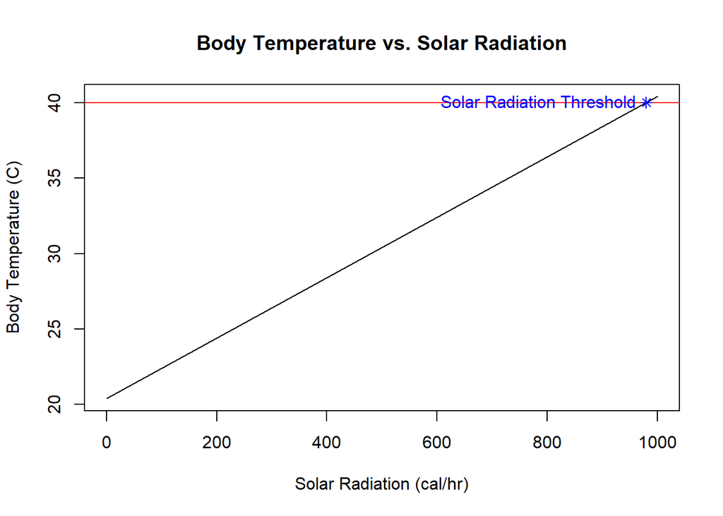

```r
q <- c(0, 500, 1000)
ben = eval(as_r(y_rmvars(be)))
plot(ben~q,
     type = "l",
     xlab = "Solar Radiation (cal/hr)",
     ylab = "Body Temperature (C)",
     main = "Body Temperature vs. Solar Radiation")
  abline(h = 40,
         col = "red")
  points(980, 40,
         pch = 8,
         col = "blue")
  text(980, 40,
       "Solar Radiation Threshold",
       pos = 2,
       col = "blue")
```

## *Problem 3*

For the last problem we will conduct a numerical analysis to find the length of time it would take for a squirrel to reach equilibrium temperature while modifying the analysis to take metabolic heat into consideration.

```r
bes = (((800+120)/50)+16)
bes <- 34.4
bel = ((800/50)+16)
bel <- 32

model.db <- function(times,y,parms){
  with(as.list(c(y, parms)), {
    db <- (q-h*(b-a)+m)/w
    list(db)
  })
}
t <- seq(from = 0, to = 120, length.out = 30)
b0 <- c(b = 34)
parms <- c(a = 16, h = 50, q = 800, w = 453, m = 120)
outputS <- ode(times = t,
               y = b0,
               func = model.db,
               parms = parms)
outputS
```

```
##          time        b
## 1    0.000000 34.00000
## 2    4.137931 34.14665
## 3    8.275862 34.23953
## 4   12.413793 34.29838
## 5   16.551724 34.33564
## 6   20.689655 34.35924
## 7   24.827586 34.37419
## 8   28.965517 34.38365
## 9   33.103448 34.38964
## 10  37.241379 34.39344
## 11  41.379310 34.39585
## 12  45.517241 34.39737
## 13  49.655172 34.39833
## 14  53.793103 34.39894
```

[output cut: 16 more lines]

```r
model.db <- function(times,y,parms){
  with(as.list(c(y, parms)), {
    db <- (q-h*(b-a))/w
    list(db)
  })
}
tl <- seq(from = 0, to = 3, length.out = 30)
b0 <- c(b = 34)
parms <- c(a = 16, h = 50, q = 800, w = 10)
outputL <- ode(times = tl,
               y = b0,
               func = model.db,
               parms = parms)
outputL
```

```
##         time        b
## 1  0.0000000 34.00000
## 2  0.1034483 33.19235
## 3  0.2068966 32.71082
## 4  0.3103448 32.42375
## 5  0.4137931 32.25268
## 6  0.5172414 32.15062
## 7  0.6206897 32.08980
## 8  0.7241379 32.05353
## 9  0.8275862 32.03191
## 10 0.9310345 32.01903
## 11 1.0344828 32.01134
## 12 1.1379310 32.00676
## 13 1.2413793 32.00403
## 14 1.3448276 32.00240
```

[output cut: 16 more lines]

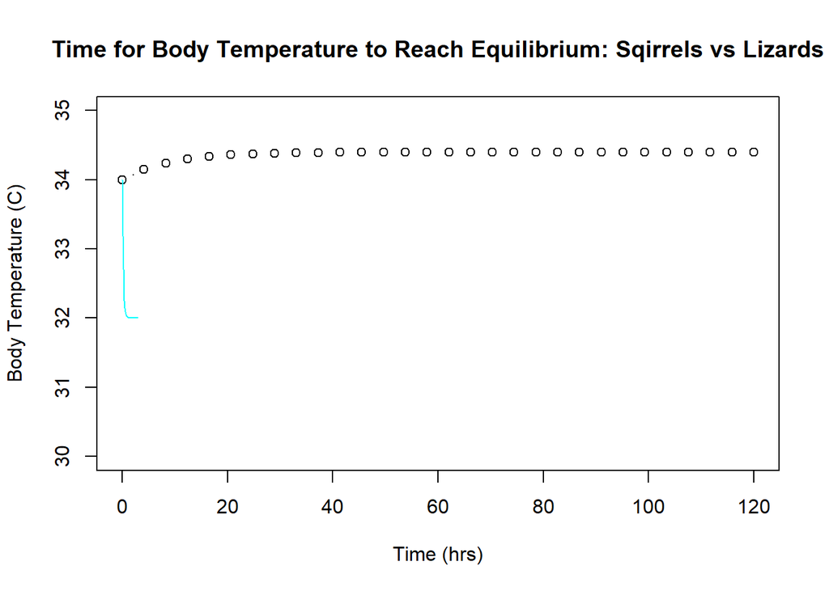

```r
plot(outputS[,2]~outputS[,1],
     type = "b",
     ylab = "Body Temperature (C)",
     ylim = c(30,35),
     xlab = "Time (hrs)",
     main = "Time for Body Temperature to Reach Equilibrium: Sqirrels vs Lizards")
lines(outputL[,2]~outputL[,1],
      col = "cyan")
```

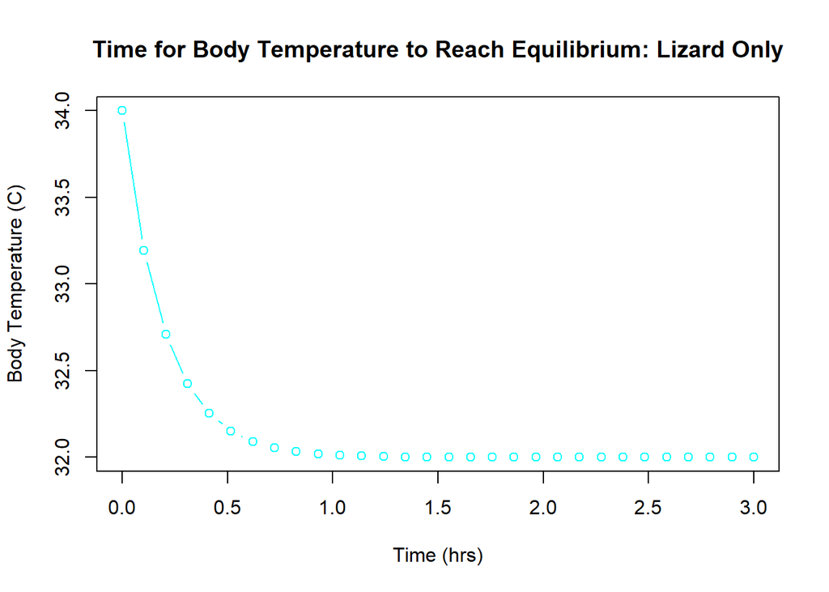

```r
plot(outputL[,2]~outputL[,1],
     type = "b",
     ylab = "Body Temperature (C)",
     xlab = "Time (hrs)",
     main = "Time for Body Temperature to Reach Equilibrium: Lizard Only",
     col = "cyan")
```